# Introduction

This analysis delves into a dataset concerning a bank marketing campaign, aiming to identify patterns and factors influencing client subscription to a term deposit. Through various visualizations and statistical assessments, the study evaluates relationships among demographic characteristics, job types, and client responses to the campaign. This exploration seeks to optimize marketing strategies and improve subscription rates by leveraging data-driven insights into client behavior and preferences.

```python
# Mounting Google Drive
from google.colab import drive
drive.mount('/content/drive')
```

```python
import pandas as pd
import numpy as np
import matplotlib.pyplot as plt
import seaborn as sns
from sklearn.tree import DecisionTreeClassifier
from sklearn.neighbors import KNeighborsClassifier
from sklearn.naive_bayes import GaussianNB
from sklearn.ensemble import RandomForestClassifier, GradientBoostingClassifier
from sklearn.linear_model import LogisticRegression
from sklearn.model_selection import train_test_split
from sklearn.preprocessing import StandardScaler, OneHotEncoder
from sklearn.compose import ColumnTransformer
from sklearn.pipeline import Pipeline
from sklearn.metrics import confusion_matrix, classification_report
from sklearn.metrics import accuracy_score, recall_score, precision_score, f1_score
```

```python
# Read data (with assignment operator)
data = pd.read_excel('/content/drive/MyDrive/IS670_data/bank-full.xlsx')
data
```

|  | age | job | marital | education | default | balance | housing | loan | contact | day | month | duration | campaign | pdays | previous | poutcome | y |
| --- | --- | --- | --- | --- | --- | --- | --- | --- | --- | --- | --- | --- | --- | --- | --- | --- | --- |
| 0 | 58 | management | married | tertiary | no | 2143 | yes | no | unknown | 5 | may | 261 | 1 | -1 | 0 | unknown | no |
| 1 | 44 | technician | single | secondary | no | 29 | yes | no | unknown | 5 | may | 151 | 1 | -1 | 0 | unknown | no |
| 2 | 33 | entrepreneur | married | secondary | no | 2 | yes | yes | unknown | 5 | may | 76 | 1 | -1 | 0 | unknown | no |
| 3 | 47 | blue-collar | married | unknown | no | 1506 | yes | no | unknown | 5 | may | 92 | 1 | -1 | 0 | unknown | no |
| 4 | 33 | unknown | single | unknown | no | 1 | no | no | unknown | 5 | may | 198 | 1 | -1 | 0 | unknown | no |
| ... | ... | ... | ... | ... | ... | ... | ... | ... | ... | ... | ... | ... | ... | ... | ... | ... | ... |
| 45206 | 51 | technician | married | tertiary | no | 825 | no | no | cellular | 17 | nov | 977 | 3 | -1 | 0 | unknown | yes |
| 45207 | 71 | retired | divorced | primary | no | 1729 | no | no | cellular | 17 | nov | 456 | 2 | -1 | 0 | unknown | yes |
| 45208 | 72 | retired | married | secondary | no | 5715 | no | no | cellular | 17 | nov | 1127 | 5 | 184 | 3 | success | yes |
| 45209 | 57 | blue-collar | married | secondary | no | 668 | no | no | telephone | 17 | nov | 508 | 4 | -1 | 0 | unknown | no |
| 45210 | 37 | entrepreneur | married | secondary | no | 2971 | no | no | cellular | 17 | nov | 361 | 2 | 188 | 11 | other | no |

45211 rows × 17 columns

```python
data.head()
```

|  | age | job | marital | education | default | balance | housing | loan | contact | day | month | duration | campaign | pdays | previous | poutcome | y |
| --- | --- | --- | --- | --- | --- | --- | --- | --- | --- | --- | --- | --- | --- | --- | --- | --- | --- |
| 0 | 58 | management | married | tertiary | no | 2143 | yes | no | unknown | 5 | may | 261 | 1 | -1 | 0 | unknown | no |
| 1 | 44 | technician | single | secondary | no | 29 | yes | no | unknown | 5 | may | 151 | 1 | -1 | 0 | unknown | no |
| 2 | 33 | entrepreneur | married | secondary | no | 2 | yes | yes | unknown | 5 | may | 76 | 1 | -1 | 0 | unknown | no |
| 3 | 47 | blue-collar | married | unknown | no | 1506 | yes | no | unknown | 5 | may | 92 | 1 | -1 | 0 | unknown | no |
| 4 | 33 | unknown | single | unknown | no | 1 | no | no | unknown | 5 | may | 198 | 1 | -1 | 0 | unknown | no |

```python
data.shape
```

```
(45211, 17)
```

```python
data.describe()
```

|  | age | balance | day | duration | campaign | pdays | previous |
| --- | --- | --- | --- | --- | --- | --- | --- |
| count | 45211.000000 | 45211.000000 | 45211.000000 | 45211.000000 | 45211.000000 | 45211.000000 | 45211.000000 |
| mean | 40.936210 | 1362.272058 | 15.806419 | 258.163080 | 2.763841 | 40.197828 | 0.580323 |
| std | 10.618762 | 3044.765829 | 8.322476 | 257.527812 | 3.098021 | 100.128746 | 2.303441 |
| min | 18.000000 | -8019.000000 | 1.000000 | 0.000000 | 1.000000 | -1.000000 | 0.000000 |
| 25% | 33.000000 | 72.000000 | 8.000000 | 103.000000 | 1.000000 | -1.000000 | 0.000000 |
| 50% | 39.000000 | 448.000000 | 16.000000 | 180.000000 | 2.000000 | -1.000000 | 0.000000 |
| 75% | 48.000000 | 1428.000000 | 21.000000 | 319.000000 | 3.000000 | -1.000000 | 0.000000 |
| max | 95.000000 | 102127.000000 | 31.000000 | 4918.000000 | 63.000000 | 871.000000 | 275.000000 |

```python
data.dtypes
```

```
age           int64
job          object
marital      object
education    object
default      object
balance       int64
housing      object
loan         object
contact      object
day           int64
month        object
duration      int64
campaign      int64
pdays         int64
previous      int64
poutcome     object
y            object
dtype: object
```

# Data Preprocessing

**1. Detect and Handle Missing Values**

```python
# Check for missing values
missing_values = data.isnull().sum()
print(missing_values)
```

```
age          0
job          0
marital      0
education    0
default      0
balance      0
housing      0
loan         0
contact      0
day          0
month        0
duration     0
campaign     0
pdays        0
previous     0
poutcome     0
y            0
dtype: int64
```

**2. Label encoding**

```python
bank_data_encoded = pd.get_dummies(data)
```

```python
encoder = OneHotEncoder(sparse=False)
bank_data_encoded = encoder.fit_transform(data.select_dtypes(include=['object']))
```

```python
for column in data.select_dtypes(include=['object']).columns:
    data[column] = data[column].astype('category').cat.codes


# Identifying categorical columns
categorical_cols = data.select_dtypes(include=['object']).columns

# Creating a column transformer with OneHotEncoder for categorical data
column_transformer = ColumnTransformer(
    transformers=[
        ('cat', OneHotEncoder(), categorical_cols)
    ],
    remainder='passthrough'  # this parameter specifies to keep the remaining columns unchanged
)

# Applying the ColumnTransformer to the data
bank_data_transformed = column_transformer.fit_transform(data)

bank_data_transformed_df = pd.DataFrame(bank_data_transformed,
                                        columns=column_transformer.get_feature_names_out())
```

```python
# Identifying categorical columns
categorical_cols = data.select_dtypes(include=['object']).columns

# Creating a column transformer with OneHotEncoder for categorical data
column_transformer = ColumnTransformer(
    transformers=[
        ('cat', OneHotEncoder(), categorical_cols)
    ],
    remainder='passthrough'  # this parameter specifies to keep the remaining columns unchanged
)

# Applying the ColumnTransformer to the data
bank_data_transformed = column_transformer.fit_transform(data)

# Convert the output back to a DataFrame for better visualization and handling
feature_names = column_transformer.get_feature_names_out()
bank_data_transformed_df = pd.DataFrame(bank_data_transformed, columns=feature_names)

# Display the transformed data frame
bank_data_transformed_df.head()
```

|  | remainder__age | remainder__job | remainder__marital | remainder__education | remainder__default | remainder__balance | remainder__housing | remainder__loan | remainder__contact | remainder__day | remainder__month | remainder__duration | remainder__campaign | remainder__pdays | remainder__previous | remainder__poutcome | remainder__y |
| --- | --- | --- | --- | --- | --- | --- | --- | --- | --- | --- | --- | --- | --- | --- | --- | --- | --- |
| 0 | 58 | 4 | 1 | 2 | 0 | 2143 | 1 | 0 | 2 | 5 | 8 | 261 | 1 | -1 | 0 | 3 | 0 |
| 1 | 44 | 9 | 2 | 1 | 0 | 29 | 1 | 0 | 2 | 5 | 8 | 151 | 1 | -1 | 0 | 3 | 0 |
| 2 | 33 | 2 | 1 | 1 | 0 | 2 | 1 | 1 | 2 | 5 | 8 | 76 | 1 | -1 | 0 | 3 | 0 |
| 3 | 47 | 1 | 1 | 3 | 0 | 1506 | 1 | 0 | 2 | 5 | 8 | 92 | 1 | -1 | 0 | 3 | 0 |
| 4 | 33 | 11 | 2 | 3 | 0 | 1 | 0 | 0 | 2 | 5 | 8 | 198 | 1 | -1 | 0 | 3 | 0 |

```python
data
```

|  | age | job | marital | education | default | balance | housing | loan | contact | day | month | duration | campaign | pdays | previous | poutcome | y |
| --- | --- | --- | --- | --- | --- | --- | --- | --- | --- | --- | --- | --- | --- | --- | --- | --- | --- |
| 0 | 58 | 4 | 1 | 2 | 0 | 2143 | 1 | 0 | 2 | 5 | 8 | 261 | 1 | -1 | 0 | 3 | 0 |
| 1 | 44 | 9 | 2 | 1 | 0 | 29 | 1 | 0 | 2 | 5 | 8 | 151 | 1 | -1 | 0 | 3 | 0 |
| 2 | 33 | 2 | 1 | 1 | 0 | 2 | 1 | 1 | 2 | 5 | 8 | 76 | 1 | -1 | 0 | 3 | 0 |
| 3 | 47 | 1 | 1 | 3 | 0 | 1506 | 1 | 0 | 2 | 5 | 8 | 92 | 1 | -1 | 0 | 3 | 0 |
| 4 | 33 | 11 | 2 | 3 | 0 | 1 | 0 | 0 | 2 | 5 | 8 | 198 | 1 | -1 | 0 | 3 | 0 |
| ... | ... | ... | ... | ... | ... | ... | ... | ... | ... | ... | ... | ... | ... | ... | ... | ... | ... |
| 45206 | 51 | 9 | 1 | 2 | 0 | 825 | 0 | 0 | 0 | 17 | 9 | 977 | 3 | -1 | 0 | 3 | 1 |
| 45207 | 71 | 5 | 0 | 0 | 0 | 1729 | 0 | 0 | 0 | 17 | 9 | 456 | 2 | -1 | 0 | 3 | 1 |
| 45208 | 72 | 5 | 1 | 1 | 0 | 5715 | 0 | 0 | 0 | 17 | 9 | 1127 | 5 | 184 | 3 | 2 | 1 |
| 45209 | 57 | 1 | 1 | 1 | 0 | 668 | 0 | 0 | 1 | 17 | 9 | 508 | 4 | -1 | 0 | 3 | 0 |
| 45210 | 37 | 2 | 1 | 1 | 0 | 2971 | 0 | 0 | 0 | 17 | 9 | 361 | 2 | 188 | 11 | 1 | 0 |

45211 rows × 17 columns

**3. Detect & Handle Outliers**

```python
def detect_outliers(df, feature):
    Q1 = df[feature].quantile(0.25)
    Q3 = df[feature].quantile(0.75)
    IQR = Q3 - Q1
    lower_bound = Q1 - 1.5 * IQR
    upper_bound = Q3 + 1.5 * IQR

    # Return a mask for rows which are outliers
    outliers = df[(df[feature] < lower_bound) | (df[feature] > upper_bound)]
    return outliers
```

```python
def handle_outliers(df, feature):
    Q1 = df[feature].quantile(0.25)
    Q3 = df[feature].quantile(0.75)
    IQR = Q3 - Q1
    lower_bound = Q1 - 1.5 * IQR
    upper_bound = Q3 + 1.5 * IQR

    df[feature] = np.where(df[feature] < lower_bound, lower_bound, df[feature])
    df[feature] = np.where(df[feature] > upper_bound, upper_bound, df[feature])
    return df
```

```python
def plot_feature(df, feature):
    plt.figure(figsize=(10, 4))
    plt.subplot(1, 2, 1)
    sns.boxplot(df[feature])
    plt.title('Before Handling Outliers')

    handle_outliers(df, feature)

    plt.subplot(1, 2, 2)
    sns.boxplot(df[feature])
    plt.title('After Handling Outliers')
    plt.show()
```

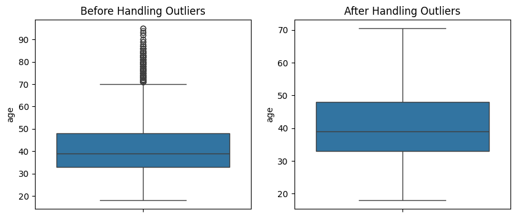

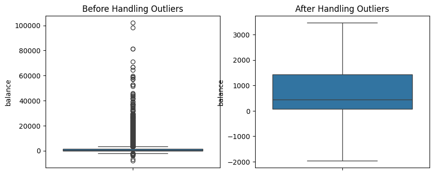

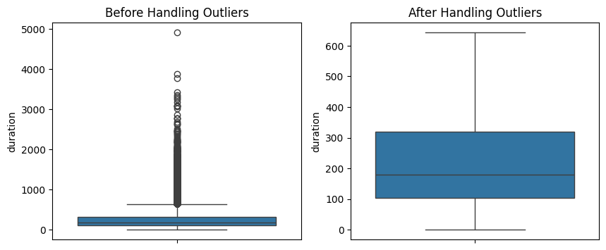

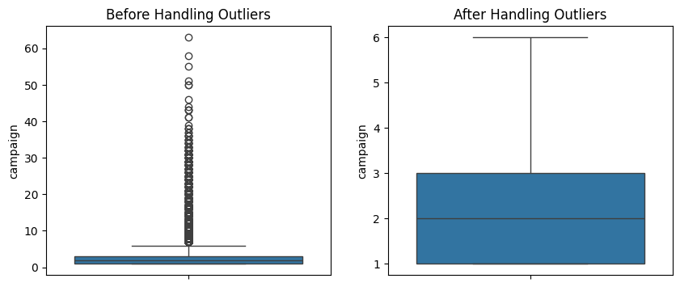

```python
for feature in ['age', 'balance', 'duration', 'campaign']:
    plot_feature(data, feature)
```

**4. Balancing the data**

```python
target_counts = data['y'].value_counts()
print(target_counts)

# Calculate the proportion of the classes
class_proportions = target_counts / len(data)
print(class_proportions)
```

```
y
0    39922
1     5289
Name: count, dtype: int64
y
0    0.883015
1    0.116985
Name: count, dtype: float64
```

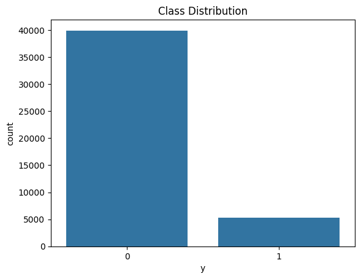

```python
# Plot the distribution of the target variable
sns.countplot(x='y', data=data)
plt.title('Class Distribution')
plt.show()
```

```python
from imblearn.over_sampling import SMOTE
from imblearn.under_sampling import RandomUnderSampler
from imblearn.pipeline import Pipeline

# Separate input features and target variable
X = data.drop('y', axis=1)
y = data['y']

# Define the resampling method
over = SMOTE(sampling_strategy=0.3)  # to oversample the minority to 30% of the majority class
under = RandomUnderSampler(sampling_strategy=0.5)  # to reduce the majority class to twice the minority

# Define the pipeline
pipeline = Pipeline(steps=[('o', over), ('u', under)])

# Apply the pipeline
X_resampled, y_resampled = pipeline.fit_resample(X, y)

# Check the new class distribution
print(pd.Series(y_resampled).value_counts())
```

```
y
0    23952
1    11976
Name: count, dtype: int64
```

**5. Feature Importance**

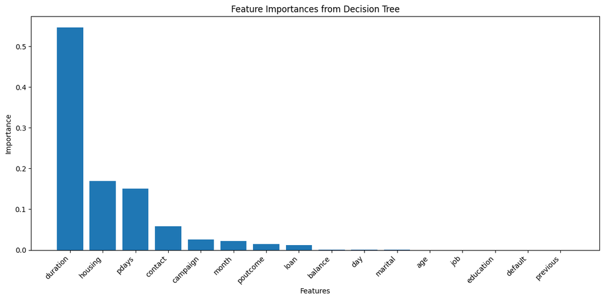

```python
# Select features and target
features = data.drop('y', axis=1)
target = data['y']

# Split the data
X_train, X_test, y_train, y_test = train_test_split(X_resampled, y_resampled, test_size=0.3, random_state=42)

# Initialize and train the Decision Tree Classifier
dt_classifier = DecisionTreeClassifier(max_depth=5, random_state=42)  # Using a moderate depth to avoid overfitting
dt_classifier.fit(X_train, y_train)

# Get feature importances
importances = dt_classifier.feature_importances_

# Create a DataFrame to visualize the feature importances
feature_importances = pd.DataFrame({'feature': X_train.columns, 'importance': importances})
feature_importances = feature_importances.sort_values('importance', ascending=False)

# Visualize the feature importances
plt.figure(figsize=(12, 6))
plt.bar(feature_importances['feature'], feature_importances['importance'])
plt.xlabel('Features')
plt.ylabel('Importance')
plt.title('Feature Importances from Decision Tree')
plt.xticks(rotation=45, ha='right')
plt.tight_layout()
plt.show()
```

**6. Calculate VIF**

```python
from statsmodels.stats.outliers_influence import variance_inflation_factor
# Separate features and target
X = data.drop('y', axis=1)
y = data['y']

# Function to calculate VIF
def calculate_vif(X):
    vif_data = pd.DataFrame()
    vif_data["Feature"] = X.columns
    vif_data["VIF"] = [variance_inflation_factor(X.values, i) for i in range(X.shape[1])]
    return vif_data

# Split data into training and testing sets (optional, as VIF is calculated on the training set)
X_train, X_test, y_train, y_test = train_test_split(X_resampled, y_resampled, test_size=0.3, random_state=42)

# Calculate VIF
vif_result = calculate_vif(X_train)
print("Initial VIF Results:")
print(vif_result)

# Set a threshold to drop features with high multicollinearity (e.g., VIF > 10)
high_vif_threshold = 10
high_vif_features = vif_result[vif_result["VIF"] > high_vif_threshold]["Feature"]

# Drop features with high VIF
X_train_reduced = X_train.drop(columns=high_vif_features)
X_test_reduced = X_test.drop(columns=high_vif_features)

# Re-calculate VIF after removing high VIF features
vif_result_reduced = calculate_vif(X_train_reduced)
print("\nVIF Results after removing high VIF features:")
print(vif_result_reduced)
```

```
Initial VIF Results:
      Feature        VIF
0         age  12.749015
1         job   2.963747
2     marital   4.560830
3   education   3.788973
4     default   1.033866
5     balance   1.834485
6     housing   2.183415
7        loan   1.186935
8     contact   1.810003
9         day   4.586374
10      month   4.816844
11   duration   2.976493
12   campaign   3.432876
```

[output cut: 20 more lines]

```python
# Check the shapes of the reduced training and test sets
print(f"X_train_reduced shape: {X_train_reduced.shape}")
print(f"X_test_reduced shape: {X_test_reduced.shape}")
print(f"y_train shape: {y_train.shape}")
print(f"y_test shape: {y_test.shape}")
```

```
X_train_reduced shape: (25149, 14)
X_test_reduced shape: (10779, 14)
y_train shape: (25149,)
y_test shape: (10779,)
```

# Data Visualization

**1. Bar Chart for Categorical Variable Distribution**

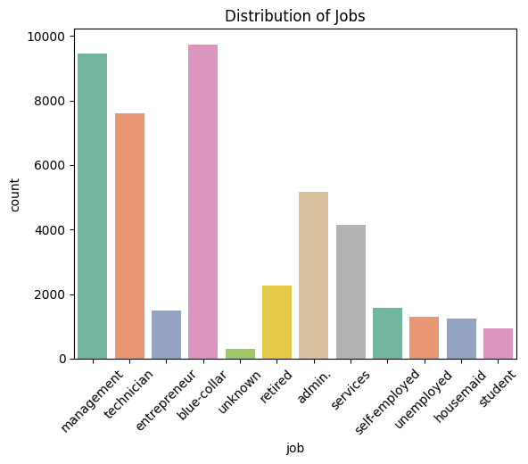

```python
sns.countplot(x='job', data=data, palette="Set2")
plt.xticks(rotation=45)
plt.title('Distribution of Jobs')
plt.show()
```

**2. Histogram for Numerical Variable Distribution**

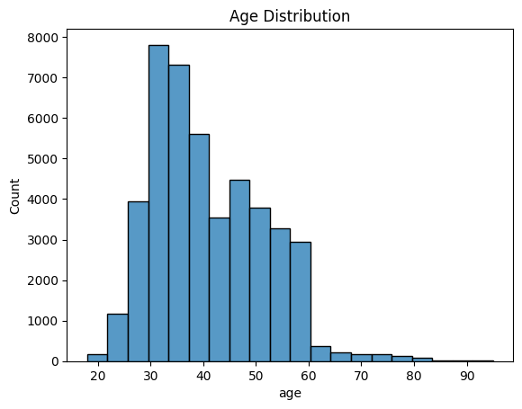

```python
sns.histplot(data['age'], bins=20, kde=False, palette="Set2")
plt.title('Age Distribution')
plt.show()
```

**3. Box Plot for Numerical Variable Spread and Outliers**

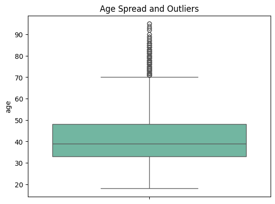

```python
sns.boxplot(y='age', data=data, palette="Set2")
plt.title('Age Spread and Outliers')
plt.show()
```

This box plot displays the distribution and spread of ages in the dataset. The box encompasses the interquartile range (IQR), highlighting that most individuals are between approximately 30 and 50 years old, with the median age around 40. The whiskers extend to the youngest and oldest ages generally observed, excluding outliers. Notably, there's a significant number of outliers above the upper whisker, indicating the presence of individuals significantly older than the general population, particularly those over the age of 70.

**4. Scatter Plot for Relationship Between Two Numerical Variables**

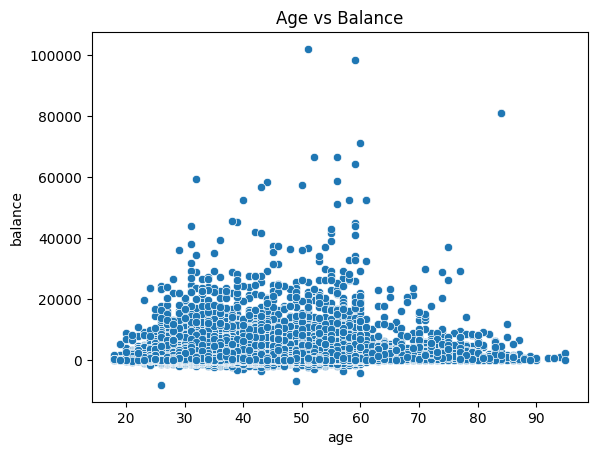

```python
sns.scatterplot(x='age', y='balance', data=data, palette="Set2")
plt.title('Age vs Balance')
plt.show()
```

This scatter plot illustrates the relationship between age and bank balance across various individuals. The data points spread primarily across younger ages with smaller bank balances, showing a dense clustering of individuals aged between 30 and 60 with balances under 20,000. As age increases, there are fewer data points, suggesting fewer older individuals in the dataset, but those present do not necessarily have higher balances. There are a few outliers with significantly high balances across the age spectrum, highlighting that high balances are not strictly associated with a specific age group.

**5. Heatmap for Correlation Matrix**

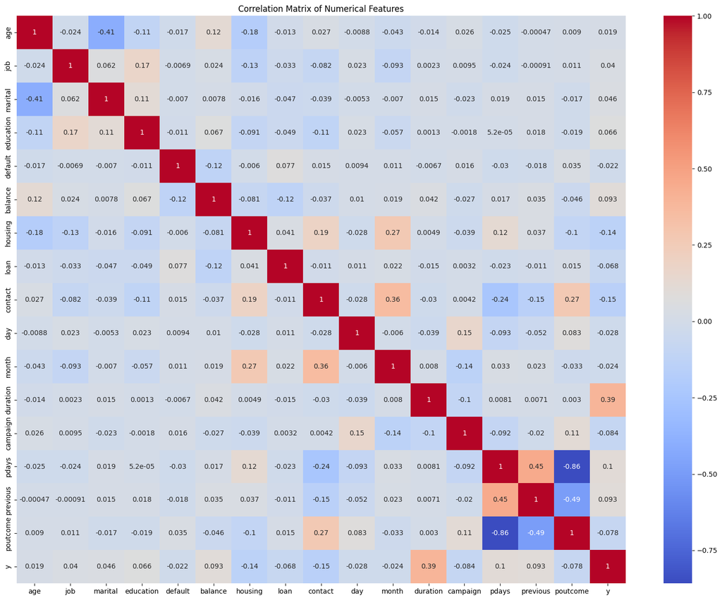

```python
# Calculate the correlation matrix
correlation_matrix = data.corr()

# Set the size of the figure
plt.figure(figsize=(20, 15))  # You can adjust the size as needed

# Draw the heatmap with annotation
sns.heatmap(correlation_matrix, annot=True, cmap='coolwarm')
plt.title('Correlation Matrix of Numerical Features')

# Show the heatmap with a defined figure size
plt.show()
```

**6. Count Plot for Categorical Variable Levels**

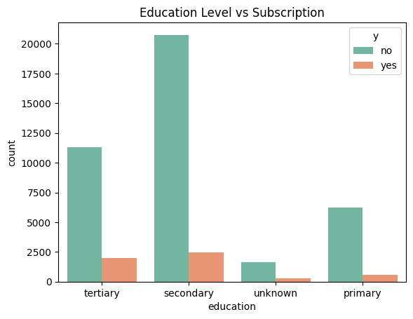

```python
sns.countplot(x='education', hue='y', data=data, palette="Set2")
plt.title('Education Level vs Subscription')
plt.show()
```

**7.Violin Plot for Duration by Subscription Status**

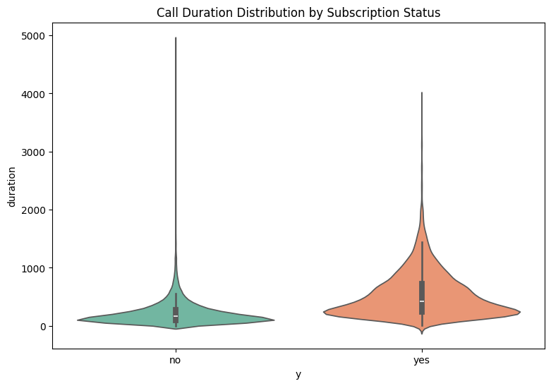

```python
# Violin Plot for Duration by Subscription Status
plt.figure(figsize=(9, 6))
sns.violinplot(x='y', y='duration', data=data, palette="Set2")
plt.title('Call Duration Distribution by Subscription Status')
plt.show()
```

**8.Count Plot for Subscription Status by Marital Status**

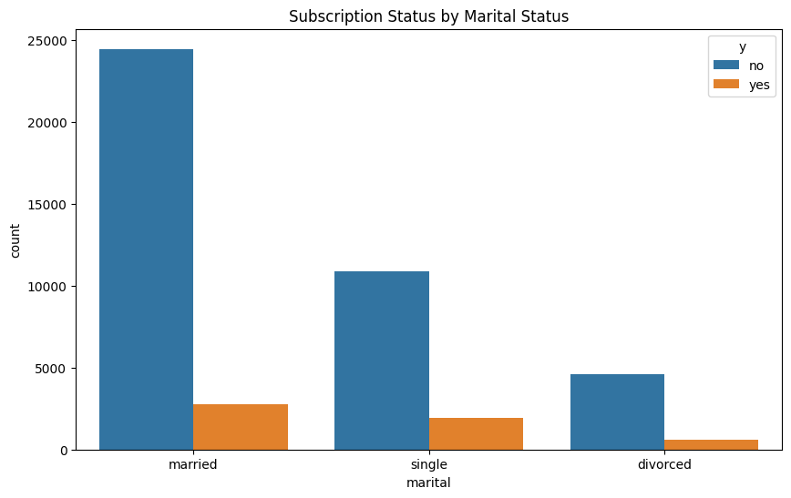

```python
# Count Plot for Subscription Status by Marital Status
plt.figure(figsize=(10, 6))
sns.countplot(x='marital', hue='y', data=data)
plt.title('Subscription Status by Marital Status')
plt.show()
```

This bar chart illustrates the subscription status distributed across different marital statuses: married, single, and divorced. The tallest bars represent the number of individuals not subscribing ("no"), with married individuals showing the highest count of non-subscribers. In contrast, the number of subscribers ("yes") is notably smaller across all marital statuses, with single individuals showing a relatively higher propensity to subscribe compared to their married and divorced counterparts. This suggests that marital status could be a significant factor in marketing strategies, with single individuals potentially representing a more receptive audience to the services offered.

**9. Bar Chart for Job Distribution**

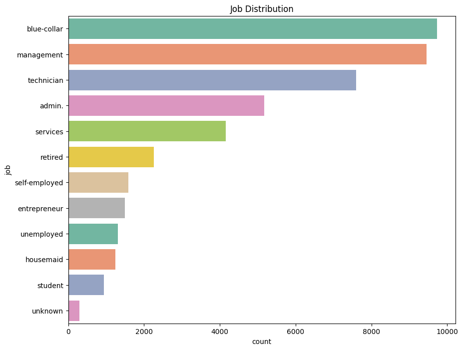

```python
# Bar Chart for Job Distribution
plt.figure(figsize=(10, 8))
sns.countplot(y='job', data=data, palette="Set2", order=data['job'].value_counts().index)
plt.title('Job Distribution')
plt.show()
```

The bar chart illustrates the job distribution among a population, revealing that the most prevalent occupations are blue-collar, management, and technician roles, indicating these are common industries within this demographic. Administrative roles also show a significant presence. On the other end of the spectrum, students, housemaids, and those with unknown job statuses represent the fewest in numbers. This distribution can help tailor marketing or policy strategies to target the most prevalent job sectors effectively.

**10. Count Plot for the Number of Clients by Marital Status**

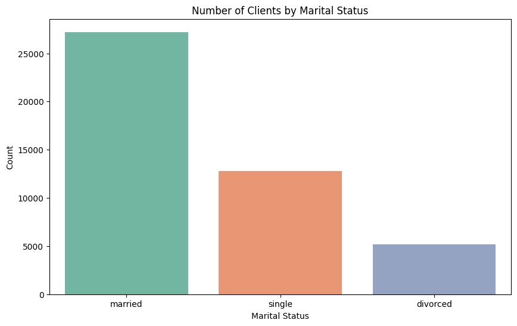

```python
plt.figure(figsize=(10, 6))
sns.countplot(x='marital', data=data, palette="Set2")
plt.title('Number of Clients by Marital Status')
plt.xlabel('Marital Status')
plt.ylabel('Count')
plt.show()
```

The bar chart provides a clear visualization of the number of clients segmented by marital status. The largest group is married clients, significantly outnumbering those who are single or divorced. This indicates that married individuals might be a key demographic for services and products aimed at households or couples, suggesting a potentially higher financial stability or interest in long-term financial planning compared to their single or divorced counterparts.

# Model Development & Evaluation

**1. Decision Tree**

```python
# Initialize the Decision Tree model
decision_tree = DecisionTreeClassifier(random_state=42)

# Fit the model on the reduced training set
decision_tree.fit(X_train_reduced, y_train)
```

```
DecisionTreeClassifier(random_state=42)
```

```python
# Make predictions on the reduced test set
y_pred = decision_tree.predict(X_test_reduced)

# Evaluate model performance
accuracy = accuracy_score(y_test, y_pred)
precision = precision_score(y_test, y_pred)
recall = recall_score(y_test, y_pred)
f1 = f1_score(y_test, y_pred)
print(f"Accuracy: {accuracy}")
print(f"Precision: {precision}")
print(f"Recall: {recall}")
print(f"F1 Score: {f1}")
print("Classification Report:")
print(classification_report(y_test, y_pred))
```

```
Accuracy: 0.8476667594396512
Precision: 0.7662195455789762
Recall: 0.7803178143295233
F1 Score: 0.7732044198895028
Classification Report:
              precision    recall  f1-score   support

           0       0.89      0.88      0.89      7192
           1       0.77      0.78      0.77      3587

    accuracy                           0.85     10779
   macro avg       0.83      0.83      0.83     10779
weighted avg       0.85      0.85      0.85     10779
```

**Experiment with Different Depths to Create More Accurate Trees**

```python
from sklearn.tree import DecisionTreeClassifier
from sklearn.metrics import accuracy_score, classification_report

# List to store accuracy for each depth
depth_results = []

# Loop through different depths from 1 to 15
for depth in range(1, 16):
    # Initialize Decision Tree with a specific depth
    decision_tree = DecisionTreeClassifier(max_depth=depth, random_state=42)

    # Train the model on the reduced training set
    decision_tree.fit(X_train_reduced, y_train)

    # Make predictions on the reduced test set
    y_pred = decision_tree.predict(X_test_reduced)

    # Calculate the accuracy for this depth
    accuracy = accuracy_score(y_test, y_pred)
    depth_results.append((depth, accuracy))

    # Print the accuracy and depth information
    print(f"Depth: {depth}, Accuracy: {accuracy:.4f}")

# Find the best depth and its corresponding accuracy
best_depth, best_accuracy = max(depth_results, key=lambda x: x[1])

# Print the best results
print(f"\nBest Depth: {best_depth}, Best Accuracy: {best_accuracy:.4f}")

# Optionally, train and evaluate a model using the best depth found
best_tree = DecisionTreeClassifier(max_depth=best_depth, random_state=42)
best_tree.fit(X_train_reduced, y_train)
y_pred_best = best_tree.predict(X_test_reduced)

print("\nClassification Report for Best Model:")
print(classification_report(y_test, y_pred_best))
```

```
Depth: 1, Accuracy: 0.7564
Depth: 2, Accuracy: 0.7701
Depth: 3, Accuracy: 0.8096
Depth: 4, Accuracy: 0.8247
Depth: 5, Accuracy: 0.8276
Depth: 6, Accuracy: 0.8424
Depth: 7, Accuracy: 0.8426
Depth: 8, Accuracy: 0.8418
Depth: 9, Accuracy: 0.8486
Depth: 10, Accuracy: 0.8526
Depth: 11, Accuracy: 0.8530
Depth: 12, Accuracy: 0.8564
Depth: 13, Accuracy: 0.8534
Depth: 14, Accuracy: 0.8562
Depth: 15, Accuracy: 0.8530

Best Depth: 12, Best Accuracy: 0.8564

Classification Report for Best Model:
              precision    recall  f1-score   support

           0       0.90      0.88      0.89      7192
           1       0.78      0.80      0.79      3587

    accuracy                           0.86     10779
   macro avg       0.84      0.84      0.84     10779
weighted avg       0.86      0.86      0.86     10779
```

**Enhancing Decision Tree Performance with Bagging Ensemble Method**

```python
from sklearn.ensemble import BaggingClassifier
from sklearn.tree import DecisionTreeClassifier
from sklearn.metrics import accuracy_score, classification_report
from sklearn.model_selection import train_test_split


# Initialize the base estimator
base_tree = DecisionTreeClassifier(random_state=42)

# Initialize the Bagging Classifier
bagging_clf = BaggingClassifier(
    estimator=base_tree,
    n_estimators=100,  # Number of trees
    max_samples=0.8,   # Percentage of data to use for each tree
    bootstrap=True,    # Use bootstrapping
    random_state=42
)

# Train the model on the training data
bagging_clf.fit(X_train_reduced, y_train)

# Predict on the test data
y_pred = bagging_clf.predict(X_test_reduced)

# Evaluate the model
accuracy = accuracy_score(y_test, y_pred)
precision = precision_score(y_test, y_pred)
recall = recall_score(y_test, y_pred)
f1 = f1_score(y_test, y_pred)
print(f"Bagging Classifier Accuracy: {accuracy}")
print(f"Precision: {precision}")
print(f"Recall: {recall}")
print(f"F1 Score: {f1}")
print("Classification Report:")
print(classification_report(y_test, y_pred))
```

```
Bagging Classifier Accuracy: 0.8833843584748121
Precision: 0.8205833791964777
Recall: 0.8313353777529969
F1 Score: 0.8259243872039884
Classification Report:
              precision    recall  f1-score   support

           0       0.92      0.91      0.91      7192
           1       0.82      0.83      0.83      3587

    accuracy                           0.88     10779
   macro avg       0.87      0.87      0.87     10779
weighted avg       0.88      0.88      0.88     10779
```

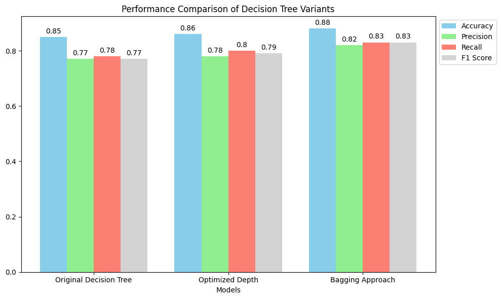

```python
import matplotlib.pyplot as plt

# Data for plotting
models = ['Original Decision Tree', 'Optimized Depth', 'Bagging Approach']
accuracy = [0.85, 0.86, 0.88]
precision = [0.77, 0.78, 0.82]
recall = [0.78, 0.80, 0.83]
f1_score = [0.77, 0.79, 0.83]

# Set up the bar chart
x = range(len(models))  # the label locations
width = 0.2  # the width of the bars

fig, ax = plt.subplots(figsize=(10, 6))
rects1 = ax.bar([p - width for p in x], accuracy, width, label='Accuracy', color='skyblue')
rects2 = ax.bar(x, precision, width, label='Precision', color= 'lightgreen')
rects3 = ax.bar([p + width for p in x], recall, width, label='Recall', color = 'salmon')
rects4 = ax.bar([p + 2*width for p in x], f1_score, width, label='F1 Score', color='lightgrey')


ax.set_xlabel('Models')
ax.set_title('Performance Comparison of Decision Tree Variants')
ax.set_xticks([p + 0.5*width for p in x])
ax.set_xticklabels(models)
ax.legend(loc='upper left', bbox_to_anchor=(1,1))  # Move the legend out of the chart


def autolabel(rects):
    for rect in rects:
        height = rect.get_height()
        ax.annotate('{}'.format(round(height, 4)),
                    xy=(rect.get_x() + rect.get_width() / 2, height),
                    xytext=(0, 3),  # 3 points vertical offset
                    textcoords="offset points",
                    ha='center', va='bottom')

autolabel(rects1)
autolabel(rects2)
autolabel(rects3)
autolabel(rects4)

fig.tight_layout()

plt.show()
```

The first model is the original Decision Tree which shows decent accuracy but slightly lower precision, recall, and F1 scores. The second model, with optimized depth, demonstrates improved recall and F1 scores, suggesting better identification of actual subscribers (positive class) without compromising on accuracy or precision. The third model, a Bagging Approach, provides the highest performance across all metrics, indicating a strong ability to generalize and correctly predict both subscribers and non-subscribers. This suggests that the Bagging Approach is most effective at minimizing false negatives and positives, leading to more reliable predictions of client subscription behavior.

**2. Naive Bayes**

```python
# Initialize the Gaussian Naive Bayes model
naive_bayes = GaussianNB()

# Train the model on the reduced training set
naive_bayes.fit(X_train_reduced, y_train)
```

```
GaussianNB()
```

```python
from sklearn.metrics import f1_score
# Make predictions on the reduced test set
y_pred = naive_bayes.predict(X_test_reduced)

# Evaluate model performance
accuracy = accuracy_score(y_test, y_pred)
precision = precision_score(y_test, y_pred)
recall = recall_score(y_test, y_pred)
f1 = f1_score(y_test, y_pred)
print(f"Accuracy: {accuracy}")
print(f"Precision: {precision}")
print(f"Recall: {recall}")
print(f"F1 Score: {f1}")
# Detailed classification report
print(classification_report(y_test, y_pred))
```

```
Accuracy: 0.7621300677242787
Precision: 0.6031874117409723
Recall: 0.8335656537496515
F1 Score: 0.6999063670411984
              precision    recall  f1-score   support

           0       0.90      0.73      0.80      7192
           1       0.60      0.83      0.70      3587

    accuracy                           0.76     10779
   macro avg       0.75      0.78      0.75     10779
weighted avg       0.80      0.76      0.77     10779
```

**Enhancing Naive Bayes Performance with Voting Ensemble Method**

```python
from sklearn.naive_bayes import GaussianNB, MultinomialNB
from sklearn.ensemble import VotingClassifier
from sklearn.preprocessing import MinMaxScaler
from sklearn.pipeline import Pipeline

pipe_mnb = Pipeline([
    ('scaler', MinMaxScaler()),
    ('mnb', MultinomialNB())
])

# GaussianNB does not require scaling
gnb = GaussianNB()

voting_clf = VotingClassifier(
    estimators=[
        ('gnb', gnb),
        ('mnb', pipe_mnb)
    ],
    voting='soft'
)
voting_clf.fit(X_train_reduced, y_train)
y_pred = voting_clf.predict(X_test_reduced)

# Re-evaluate the classifier
accuracy = accuracy_score(y_test, y_pred)
precision = precision_score(y_test, y_pred)
recall = recall_score(y_test, y_pred)
f1 = f1_score(y_test, y_pred)
print(f"Voting Classifier Accuracy (Soft Voting): {accuracy}")
print(f"Precision: {precision}")
print(f"Recall: {recall}")
print(f"F1 Score: {f1}")
print("Classification Report (Soft Voting):")
print(classification_report(y_test, y_pred))
```

```
Voting Classifier Accuracy (Soft Voting): 0.7870860005566379
Precision: 0.6466848319709355
Recall: 0.7939782548090326
F1 Score: 0.7128019021399074
Classification Report (Soft Voting):
              precision    recall  f1-score   support

           0       0.88      0.78      0.83      7192
           1       0.65      0.79      0.71      3587

    accuracy                           0.79     10779
   macro avg       0.77      0.79      0.77     10779
weighted avg       0.81      0.79      0.79     10779
```

**Enhancing Naive Bayes Performance with Stacking Ensemble Method**

```python
from sklearn.ensemble import StackingClassifier
# Define the base models
base_models = [
    ('naive_bayes', GaussianNB()),
    ('logistic_regression', LogisticRegression(random_state=42)),
    ('decision_tree', DecisionTreeClassifier(random_state=42))
]

# Define the final estimator
final_estimator = LogisticRegression(random_state=42)

# Create the stacking classifier
stacked_model = StackingClassifier(estimators=base_models, final_estimator=final_estimator, cv=5)

# Train the stacked model
stacked_model.fit(X_train_reduced, y_train)

# Make predictions
y_pred = stacked_model.predict(X_test_reduced)

# Evaluate the model
accuracy = accuracy_score(y_test, y_pred)
precision = precision_score(y_test, y_pred)
recall = recall_score(y_test, y_pred)
f1 = f1_score(y_test, y_pred)
print("Accuracy of Stacked Model:", accuracy)
print("Precision:", precision)
print("Recall:", recall)
print("F1 Score:", f1)
print("Classification Report:\n", classification_report(y_test, y_pred))
```

[output not shown]

```
Accuracy of Stacked Model: 0.8560163280452732
Precision: 0.7919655667144907
Recall: 0.7694452188458322
F1 Score: 0.7805429864253394
Classification Report:
               precision    recall  f1-score   support

           0       0.89      0.90      0.89      7192
           1       0.79      0.77      0.78      3587

    accuracy                           0.86     10779
   macro avg       0.84      0.83      0.84     10779
weighted avg       0.86      0.86      0.86     10779
```

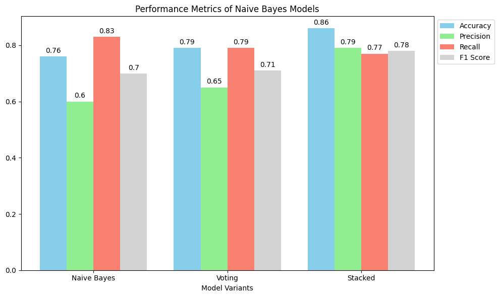

```python
# Model names
models = ['Naive Bayes', 'Voting', 'Stacked']

# Performance metrics
accuracy = [0.76, 0.79, 0.86]
precision = [0.60, 0.65, 0.79]
recall = [0.83, 0.79, 0.77]
f1_score = [0.70, 0.71, 0.78]

x = range(len(models))
width = 0.2  # the width of the bars

fig, ax = plt.subplots(figsize=(10, 6))
rects1 = ax.bar([p - 1.5*width for p in x], accuracy, width, label='Accuracy', color='skyblue')
rects2 = ax.bar([p - 0.5*width for p in x], precision, width, label='Precision', color='lightgreen')
rects3 = ax.bar([p + 0.5*width for p in x], recall, width, label='Recall', color='salmon')
rects4 = ax.bar([p + 1.5*width for p in x], f1_score, width, label='F1 Score', color='lightgrey')


ax.set_xlabel('Model Variants')
ax.set_title('Performance Metrics of Naive Bayes Models')
ax.set_xticks(x)
ax.set_xticklabels(models)
ax.legend(loc='upper left', bbox_to_anchor=(1,1))  # Move the legend out of the chart


def autolabel(rects):
    for rect in rects:
        height = rect.get_height()
        ax.annotate('{}'.format(round(height, 4)),
                    xy=(rect.get_x() + rect.get_width() / 2, height),
                    xytext=(0, 3),  # 3 points vertical offset
                    textcoords="offset points",
                    ha='center', va='bottom')

# Call the function to attach labels
autolabel(rects1)
autolabel(rects2)
autolabel(rects3)
autolabel(rects4)

fig.tight_layout()
plt.show()
```